# Survival data challenge, starting kit

Florent Chuffart

2019-01-23

# 1 Overview of the Survival challenge

## 1.1 How to participate?

The challenge is hosted on the codalab platform:

https://competitions.codalab.org/competitions/21360?secret_key=1b0893b2-c695-4c9b-ae33-334ac7a056ac

To participate, you need to:

1- create an acount on the codalab platform

2- subscribe to the *Survival challenge*

3- constitute teams (up to 4 people) and design a team coordinator on the platform

## 1.2 How to start?

In the [participate](https://competitions.codalab.org/competitions/21360#participate-get_starting_kit) window, go in the *Files* tab and download the public data.

Save the 3 files contained into **challenge_ssd2019_public_data** in the same folder than the starting kit.

## 1.3 What is the aim of the challenge?

The challenge is to classify a subset of cancer patients according to discriminating survival groups. You need to submit your classification to the codalab platform. A cox survival p-value will be computed according to your classification, this corresponds to your score on the leaderboard. Try to improve you score!

You will participate to 2 challenges:

- Challenge #1: Exploration phase. You need to classify the patients with ‘challenge1’ `exp_grp$sets` id.
- Challenge #2: Final test phase. You need to classify the patients with ‘challenge2’ `exp_grp$sets` id.

Use the training set (‘training’ id in `exp_grp$sets`) to determine your best classification model.

**Warning**

- You have only **one** opportunity to submit to Challenge 2, to avoid over fitting.
- The Challenge 2 will be opened from 5pm to 8pm.

## 1.4 How do I get information?

Section 2 indicates where the data are coming from.

Section 3 and 4 explain how to load the data , what are the data, and how to identify the patients.

Section 5 and 6 display exemples of data exploration.

Please go to section 7 to see an exemple of result submission on the cadalab platform.

## 1.5 What will be the evaluation?

At 8pm, you will have to return a report of 5 pages maximum including an introduction, the methods you used, and a discussion of the results obtained.

You will be evaluated on the quality of your classification (results submission on the codalab paltform), your creativity to achieve this goal and the clarity of your report.

# 2 References

Data are coming from the TCGA (The cancer genome atlas). They were extracted from severla cohorts of patients. Here are TCGA Study Abbreviations corresponding to each cancer:

https://gdc.cancer.gov/resources-tcga-users/tcga-code-tables/tcga-study-abbreviations

# 3 Loading data

`exp_grp` corresponds to metadata associated with the patients (2049 patients).

`data` corresponds to gene expression data for each pations patients (9466 genes).

`pf` corresponds to informations related to each gene.

```r
exp_grp = readRDS(file="challenge_ssd2019_e.rds")
head(exp_grp)
dim(exp_grp)
data    = readRDS(file="challenge_ssd2019_d.rds")
head(data)
dim(data)
pf      = readRDS(file="challenge_ssd2019_p.rds")
head(pf)
dim(pf)
```

# 4 Tumoral and non tumoral samples

```r
idx_nt = rownames(exp_grp)[exp_grp$tissue_status == "normal"]
idx_tu = rownames(exp_grp)[exp_grp$tissue_status == "tumoral"]
```

```r
idx_training = rownames(exp_grp)[exp_grp$sets == "training"]
length(idx_training)
idx_challenge1 = rownames(exp_grp)[exp_grp$sets == "challenge1"]
length(idx_challenge1)
idx_challenge2 = rownames(exp_grp)[exp_grp$sets == "challenge2"]
length(idx_challenge2)
```

# 5 PCA

## 5.1 Non tumoral tissues

Guttman effect

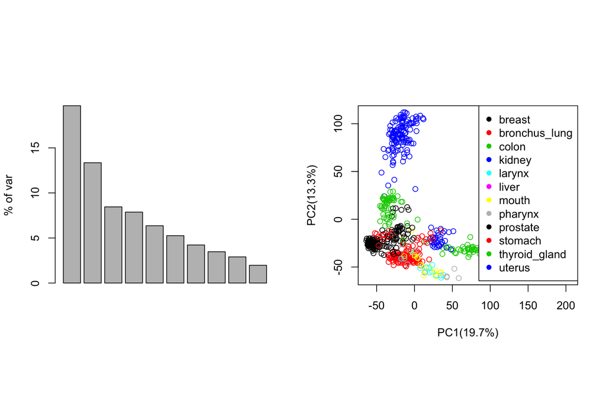

```r
pca = prcomp(t(data[,idx_nt]), scale=FALSE)
v = pca$sdev * pca$sdev
p = v / sum(v) * 100


col = as.numeric(as.factor(exp_grp[idx_nt,]$tissue_group_level1))
layout(matrix(1:2,1), respect=TRUE)
barplot(p[1:10], ylab="% of var")

i = 1
j = 2
plot(pca$x[,i], pca$x[,j],
  xlab=paste0("PC", i, "(", signif(p[i], 3), "%)"),
  ylab=paste0("PC", j, "(", signif(p[j], 3), "%)"),
  col=col
)
legend("topright", pch=16, col=1:length(unique(exp_grp[idx_nt,]$tissue_group_level1)), levels(as.factor(exp_grp[idx_nt,]$tissue_group_level1)))
```

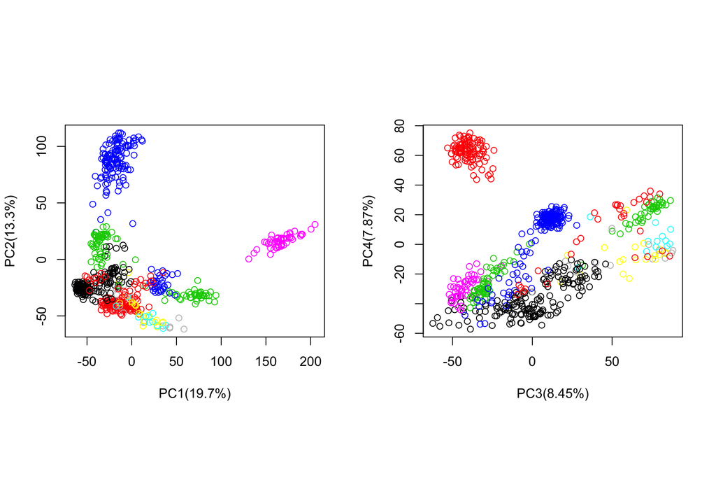

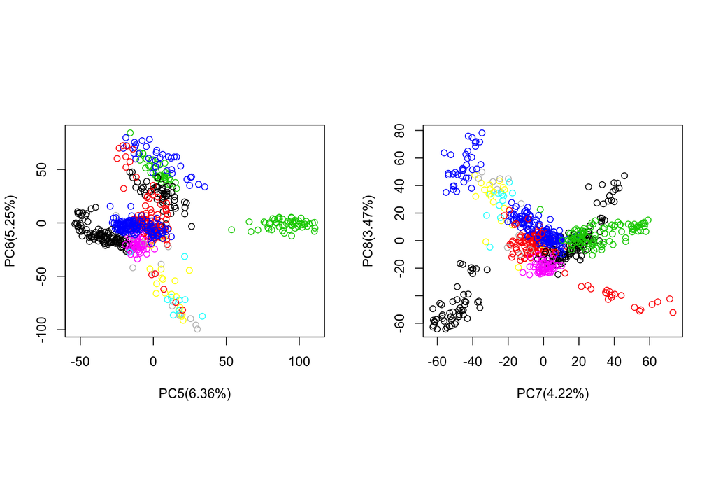

```r
for (i in c(1,3,5,7)) {
  j = i+1
  plot(pca$x[,i], pca$x[,j],
    xlab=paste0("PC", i, "(", signif(p[i], 3), "%)"),
    ylab=paste0("PC", j, "(", signif(p[j], 3), "%)"),
    col=col
  )
}
```

## 5.2 Tumoral tissues

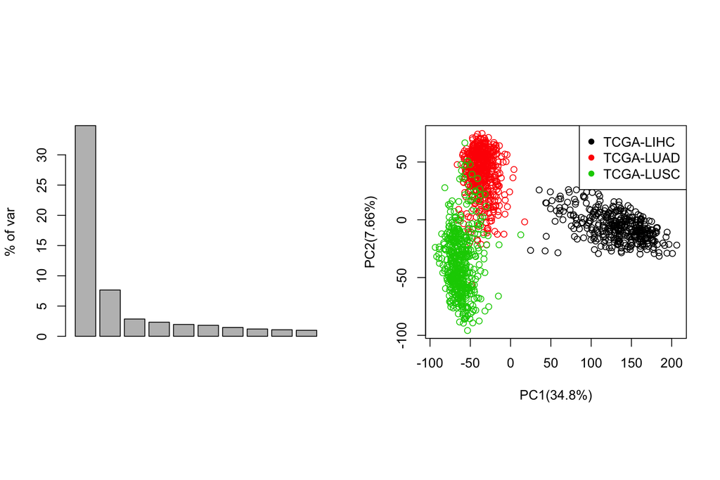

```r
pca = prcomp(t(data[,idx_tu]), scale=FALSE)
v = pca$sdev * pca$sdev
p = v / sum(v) * 100


col = as.numeric(as.factor(exp_grp[rownames(pca$x),]$main_gse_number))
layout(matrix(1:2,1), respect=TRUE)
barplot(p[1:10], ylab="% of var")

i = 1
j = 2
plot(pca$x[,i], pca$x[,j],
  xlab=paste0("PC", i, "(", signif(p[i], 3), "%)"),
  ylab=paste0("PC", j, "(", signif(p[j], 3), "%)"),
  col=col
)
legend("topright", pch=16, col=1:length(unique(exp_grp[rownames(pca$x),]$main_gse_number)), levels(as.factor(exp_grp[rownames(pca$x),]$main_gse_number)))
```

# 6 Survival

We plot survival according to:

- cancer type
- sex
- cancer stage
- level of expression of ATAD2 gene

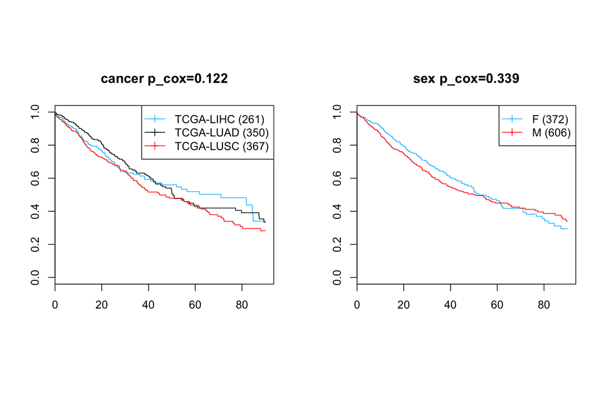

```r
layout(matrix(1:2, 1), respect=TRUE)
scurve(exp_grp$os, exp_grp$main_gse_number, main="cancer")
scurve(exp_grp$os, exp_grp$sex, main="sex")
```

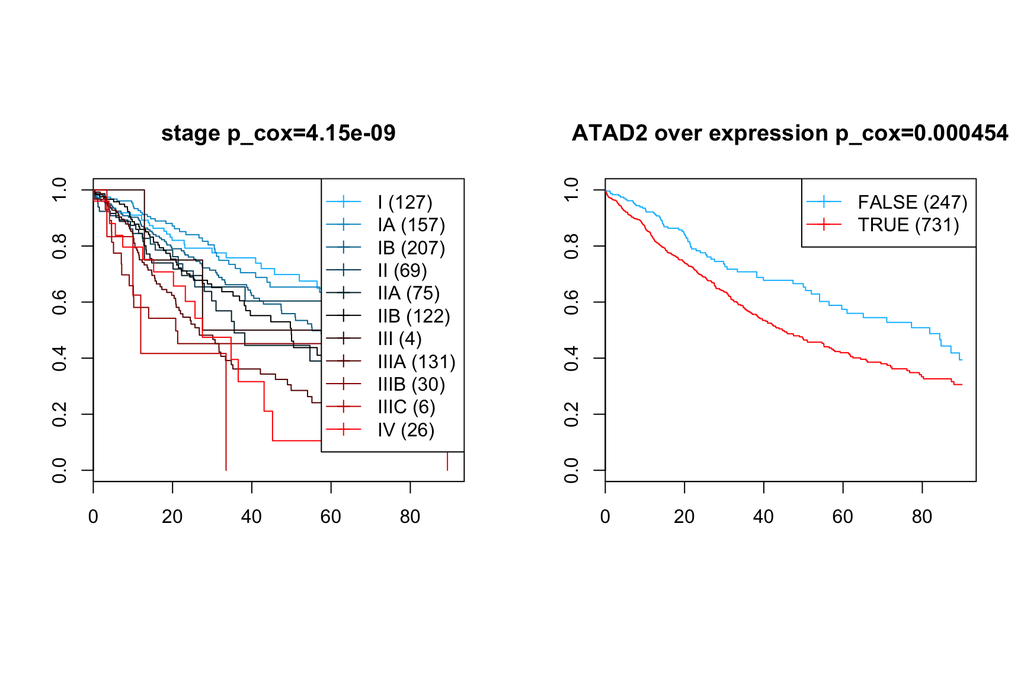

```r
scurve(exp_grp$os, exp_grp$tnm_stage, main="stage")
scurve(exp_grp$os, data["ATAD2",rownames(exp_grp)] > 10.5, main="ATAD2 over expression")
```

# 7 Export results for submission

Here, we define survival groups according to ATAD2 expression. Then, we export results for challenge 1 and challenge 2. The zip files have to be submit on the coda lab interface > Participate > Submit / View Results > Submit

Warning:

- You have only **one** opportunity to submit to Challenge 2, to avoid over fitting.
- The Challenge 2 is only reachable after 5pm.

## 7.1 Challenge 1

```r
# Define groups
idx = rownames(exp_grp)[exp_grp$sets == "challenge1"]
grps = data["ATAD2",idx] < 10.5
names(grps) = idx

# Export grps
saveRDS(grps, "grps.rds")
zip("grps_chal1.zip", "grps.rds")
```

## 7.2 Challenge 2

```r
# Define groups
idx = rownames(exp_grp)[exp_grp$sets == "challenge2"]
grps = data["ATAD2",idx] < 10.5
names(grps) = idx

# Export grps
saveRDS(grps, "grps.rds")
zip("grps_chal2.zip", "grps.rds")
```